# Quantitative Benchmarking for Theory Exploration

Chris Warburton  
University of Dundee  
c.m.warburton@dundee.ac.uk

# Motivation

- Automated mathematical *calculation* is routine
- Automated mathematical *proof* is common in some fields (e.g. programming)
- Automated mathematical *exploration* is rare

Why exploration?

- Aids understanding/proving/etc. of a theory/library
- Opportunity to move expertise into tools
- Can *surprise* us

# (Automated) Theory Exploration

- Takes as input a set of definitions in some formal language
  - e.g. a functional programming library:

```
append(nil, ys)         = ys
append(cons(x, xs), ys) = cons(x, append(xs, ys))
   map(f, nil)          = nil
   map(f, cons(x, xs))  = cons(f(x), map(f, xs))
```

- Outputs interesting conjectures about those definitions
  - e.g. `map` distributes over `append` (interesting for parallel computation)

```
map(f, append(xs, ys)) = append(map(f, xs), map(f, ys))
```

Problems:

- Inefficient (e.g. uses brute-force)
- Ambiguous goals/definitions (e.g. what is "interesting"?)

# Existing Approaches

- Generating conjectures in first order logic (e.g. Graffiti, HR)
- Our focus is higher-order logic (functional programming, proof assistants)
- Three main systems for HOL:
  - IsaCoSy: Isabelle, constraint solving (Johansson, Dixon, and Bundy 2009)
  - IsaScheme: Isabelle, templates/schemas (Montano et al., n.d.)
  - QuickSpec: Haskell, random testing (Claessen, Smallbone, and Hughes 2010)
    - Used by Hipspec(Claessen et al. 2013) and Hipster(Johansson et al. 2014)

# Questions

1. How do we evaluate conjectures?
   - Finding theorems is trivial!
2. How do we evaluate/compare sets of conjectures?
   - We want to find more than one conjecture
   - Repeating a good conjecture 100 times isn't a good set!
3. How do we evaluate/compare theory exploration systems?
   - Brute-force can optimise anything
   - How do we compare "practical" performance?

# Q1. Evaluating Conjectures

What is "interesting"?

In theory:

- Important for evaluating performance in novel domains
- Many competing/complementary measures proposed (Colton, Bundy, and Walsh 2000)
- Some objective (e.g. statement vs proof size), some subjective (e.g. compression progress)

In practice:

- Existing tools are far from human performance
- Comparing tool's output to human's output is challenge enough
- Simplifying assumptions:
  - For known theories, "interesting" ~= "appears in existing corpus"
  - Performance should generalise to novel theories (modulo overfitting)

# Q2. Evaluating Sets of Conjectures

Given a corpus of known theorems/conjectures and a set of proposed conjectures:

- Precision is % of proposed which are in corpus
- Recall is % of corpus which was proposed
- Used in previous work

# Existing Evaluations

- Isabelle libraries used as corpus
- Compare IsaCoSy, IsaScheme and Hipspec (QuickSpec)

Problems:

- Only two theories used (natural numbers and lists)
- Theories are small
  - Natural numbers: ~4 definitions, 12 theorems
  - Lists: ~6 definitions, 9 theorems

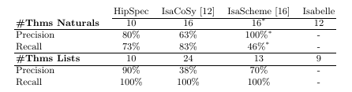

# Our Proposal

- Use a larger corpus of definitions and statements
- Generate theories of a desired size (number of definitions) by sampling
- Identify corpus theorems involving those definitions
- Average precision/recall over many samples

Benefits:

- Replaces ambiguity with empirical, numerical measurements
- Shows variance
- More likely to generalise

# Q3. Evaluating Systems

- No single objective to maximise
  - Are we prepared to wait longer for quality?
- Important criteria:
  - Precision
  - Recall
  - Run time
  - Variance
  - Scaling behaviour

Sampling theories from a large corpus provides two opportunities:

- Pairwise difference of systems, given the same samples
- Measure scaling by varying #definitions in the samples

# Corpus Source

We chose the TIP theorem proving benchmark (Claessen et al. 2015)

- Separates definitions from theorem statements
- Order of magnitude larger than before (219 definitions, 343 statements)
- Higher-order (e.g. includes `map`)
- Includes problems from the theorem proving literature
- Includes problems relevant to programming/verification
- Simple format, with translation to Haskell, Isabelle, etc.
- Not written by us (no cheating!)

# Generating Our Corpus

- Pool together all definitions (~3500)
- Add constructors/destructors for datatypes
- Remove duplicate definitions (leaves 269)
- Sampler for definitions (with > 0 theorems)
- Query theorems for a given sample
- We also provide automate the whole exploration and evaluation process:
  - Sampling
  - Translating to appropriate language
  - Timing exploration
  - Extracting conjectures from output
  - Comparing to corpus

# Example

We have applied our benchmarking methodology to QuickSpec

[figure not shown]

# Observations

- Lots of room for improvement!
- Runtime depends heavily on the theory contents
- High variance (mostly very fast or very slow), increasing with theory size
- ~85% take <200s
- Above 200s, most time out
- Further investigation needed:
  - What causes a long-running theory?
  - Precision/recall: Currently 0%, corpus querying too coarse-grained

# Potential Improvement

- QuickSpec tries every combination of the inputs
- Choosing a *subset* to explore improves efficiency by avoiding useless combinations
  - Incomplete, reduces recall
- Need *smart* ways to choose subsets
  - Combine *relevance filtering* with *recurrent clustering*
- Currently implemented: experiments pending

# Summary

1. How do we evaluate conjectures?
   - Use known theories and look up in corpus
2. How do we evaluate/compare sets of conjectures?
   - Precision/recall against large corpus
3. How do we evaluate/compare theory exploration systems?
   - Repeated sampling from a large benchmark
   - Gather statistics on runtime, precision and recall
   - Compare systems using pairwise difference
4. Narrowing down search space can improve efficiency

# Future Work

- Extending to other implementations/languages
- Use benchmark to evaluate/compare new approaches
- Machine learning
  - Benchmark as training data
  - Benchmark as fitness function
  - Hygiene to avoid overfitting!
- Study applications of theory exploration to realistic problems
  - Lemma generation has been studied
  - Program optimisation
  - Abstraction discovery

# Resources

All code available at chriswarbo.net/git and github.com/Warbo

- `theory-exploration-benchmarks`: TIP -> theory exploration converter
- `haskell-te`: Benchmarking for QuickSpec
- `isaplanner-tip`: Benchmarking for IsaCoSy
- `mlspec`: Exploring subsets

All results (modulo hardware speed) are reproducible using Nix. Please let me know if you have any problems!

# Questions?

# References

Claessen, Koen, Moa Johansson, Dan Rosén, and Nicholas Smallbone. 2013. “Automating inductive proofs using theory exploration.” In *Automated Deduction–CADE-24*, 392–406. Springer.

———. 2015. “TIP: tons of inductive problems.” In *Conferences on Intelligent Computer Mathematics*, 333–37. Springer.

Claessen, Koen, Nicholas Smallbone, and John Hughes. 2010. “QuickSpec: Guessing Formal Specifications Using Testing.” In *Tests and Proofs*, edited by Gordon Fraser and Angelo Gargantini, 6143:6–21. Lecture Notes in Computer Science. Springer Berlin Heidelberg. doi:10.1007/978-3-642-13977-2_3.

Colton, Simon, Alan Bundy, and Toby Walsh. 2000. “On the notion of interestingness in automated mathematical discovery.” *International Journal of Human-Computer Studies* 53 (3). Elsevier: 351–75.

Johansson, Moa, Lucas Dixon, and Alan Bundy. 2009. “Isacosy: Synthesis of inductive theorems.” In *Workshop on Automated Mathematical Theory Exploration (Automatheo)*.

Johansson, Moa, Dan Rosén, Nicholas Smallbone, and Koen Claessen. 2014. “Hipster: Integrating Theory Exploration in a Proof Assistant.” In *Intelligent Computer Mathematics*, edited by StephenM. Watt, JamesH. Davenport, AlanP. Sexton, Petr Sojka, and Josef Urban, 8543:108–22. Lecture Notes in Computer Science. Springer International Publishing. doi:10.1007/978-3-319-08434-3_9.

Montano, Omar, Roy Mccasl, Lucas Dixon, and Alan Bundy. n.d. “Scheme-based Definition and Conjecture Synthesis for Inductive Theories.” Citeseer.